# project3

group1

March 16, 2018

## Our Project

```r
raw.data <- read_csv('https://raw.githubusercontent.com/brian-cuny/607project3/master/multipleChoiceResponses.csv', na=c('', 'NA')) %>%
  subset(DataScienceIdentitySelect == 'Yes' & CodeWriter == 'Yes') %>%
  rowid_to_column('id')
```

### Profile of a Data Scientist: Justin

### Learning Platform Usefulness: Hovig

### Learning Categories: Brian

This subset of data examines how data scientists learned their core skill set. Each data scientist was asked to assign each category a percent from 0 to 100 indicating how much of their education was made up of this source.

First, a list of categories was extrated and formatted.

```r
tidy.names <- names(raw.data)[61:66] %>%
  str_extract('(?<=LearningCategory)(\\w+)') %>%
  str_replace_all('(?<=[a-z])([A-Z])', '_\\1') %>%
  tolower()
tidy.names %>% kable()
```

| x |
| --- |
| self_taught |
| online_courses |
| work |
| university |
| kaggle |
| other |

The data was tidied and the categories were converted to factors, to aid in analysis.

```r
tidy.data <- raw.data %>%
  select(c(1, 61:66)) %>%
  setNames(c('id', tidy.names)) %>%
  gather('category', 'percent', 2:7, na.rm=TRUE)

tidy.data$percent %<>% as.numeric()

tidy.data$category %<>% factor(levels=tidy.names, ordered=TRUE)
tidy.data %>% head(10) %>% kable()
```

| id | category | percent |
| --- | --- | --- |
| 1 | self_taught | 0 |
| 2 | self_taught | 30 |
| 3 | self_taught | 50 |
| 4 | self_taught | 30 |
| 5 | self_taught | 10 |
| 6 | self_taught | 30 |
| 7 | self_taught | 30 |
| 8 | self_taught | 40 |
| 9 | self_taught | 15 |
| 10 | self_taught | 80 |

Summary statistics tell an intersting story. No source averaged more than 50% of the sets learning sources. This would seem to indicate that data scientists learn from a diverse set of sources. The ‘other’ category’s mean is nearly 0 also indicating that the other categories account for nearly all learning sources.

```r
tidy.summary.data <- tidy.data %>%
  group_by(category) %>%
  summarise(avg=mean(percent), sd=sd(percent))
tidy.summary.data %>% kable()
```

| category | avg | sd |
| --- | --- | --- |
| self_taught | 35.144046 | 25.031918 |
| online_courses | 20.913201 | 21.314789 |
| work | 19.651230 | 19.842592 |
| university | 17.970174 | 22.666613 |
| kaggle | 5.494971 | 10.822363 |
| other | 1.031872 | 6.140186 |

The boxplots support the summary statistics. Each category has numerous upper ourliers indicating that data scientists who learned most or entirely from one source were rare.

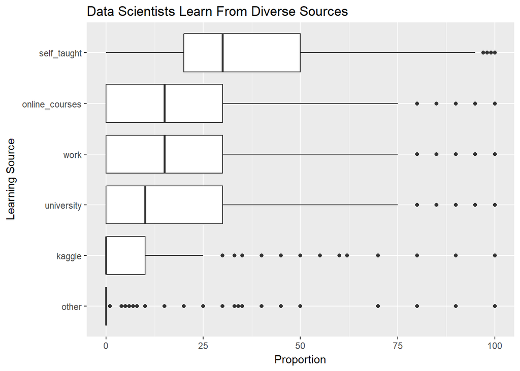

```r
ggplot(tidy.data) +
  geom_boxplot(aes(category, percent)) +
  xlim(tidy.names %>% rev()) +
  coord_flip() +
  labs(x='Learning Source',
       y='Proportion',
       title='Data Scientists Learn From Diverse Sources'
  )
```

The final more clearly shows the diversity in learning styles. This indicates that not only do data scientists learn from a variety of sources, but every data scientist’s sources vary in importance. This highlights the idea that there is not right or wrong way to learn to become a data scientist. At the same time, as the four major categories amount for nearly 100% of education, this means that there are no “secret” learning sources.

[figure not shown]

```r
ggplot(tidy.data) +
  geom_bar(aes(category, fill=percent %>%
                                round_any(10) %>%
                                factor(seq(0, 100, 10))
              ), position=position_fill(reverse=TRUE)
          ) +
  scale_color_brewer(palette='Set1') +
  theme(axis.text.x=element_text(angle=45, hjust=1)) +
  labs(x='Learning Source',
       y='Proportion',
       title='Data Scientists Learn From Diverse Sources',
       fill='Percent'
  )
```

### Common Job Algorithms: Rose

This subset of data examines common algorithms and methods used by data scientists.

First, the proper data is subset.

```r
data.rose <- raw.data %>%
  select(c(1, 80:81, 134:167))

tidy.names <- c(names(data.rose)[1:4],
                names(data.rose)[5:37] %>%
                  str_extract('(?<=WorkMethodsFrequency)(.+)')
                )

melt.dt <- data.rose %>%
  setNames(tidy.names) %>%
  gather('WorkMethodsFrequency', 'Frequency', 5:37)
melt.dt %>% head(10) %>% kable()
```

| id | WorkDatasetSize | WorkAlgorithmsSelect | WorkMethodsSelect | WorkMethodsFrequency | Frequency |
| --- | --- | --- | --- | --- | --- |
| 1 | 10GB | Neural Networks,Random Forests,RNNs | Association Rules,Collaborative Filtering,Neural Networks,PCA and Dimensionality Reduction,Random Forests | A/B | NA |
| 2 | 1GB | Bayesian Techniques,Decision Trees,Random Forests,Regression/Logistic Regression | A/B Testing,Bayesian Techniques,Data Visualization,Decision Trees,Ensemble Methods,Logistic Regression,Markov Logic Networks,Naive Bayes,Neural Networks,Random Forests,Simulation,Time Series Analysis | A/B | Sometimes |
| 3 | 100GB | Bayesian Techniques,Regression/Logistic Regression | A/B Testing,Bayesian Techniques,Decision Trees,Naive Bayes,Random Forests | A/B | Often |
| 4 | 1GB | CNNs,Neural Networks | CNNs,Data Visualization,Neural Networks,PCA and Dimensionality Reduction | A/B | NA |
| 5 | 1GB | Decision Trees,Ensemble Methods,Random Forests,Regression/Logistic Regression | A/B Testing,Collaborative Filtering,Cross-Validation,Data Visualization,Logistic Regression,Random Forests,Text Analytics,Time Series Analysis | A/B | Rarely |
| 6 | 100MB | Evolutionary Approaches | Data Visualization,Evolutionary Approaches,Logistic Regression,Time Series Analysis | A/B | NA |
| 7 | 1TB | Decision Trees,RNNs,SVMs | Cross-Validation,Data Visualization,Decision Trees,PCA and Dimensionality Reduction,RNNs,Segmentation,SVMs,Time Series Analysis | A/B | NA |
| 8 | 10TB | CNNs,Decision Trees,Ensemble Methods,Gradient Boosted Machines,Neural Networks,Random Forests,SVMs | CNNs,Cross-Validation,Data Visualization,Decision Trees,Ensemble Methods,GANs,Gradient Boosted Machines,kNN and Other Clustering,Logistic Regression,Naive Bayes,Neural Networks,PCA and Dimensionality … | A/B | NA |
| 9 | NA | NA | NA | A/B | NA |
| 10 | 10GB | Decision Trees,Ensemble Methods,Random Forests,Regression/Logistic Regression,SVMs | Cross-Validation,Data Visualization,Decision Trees,Ensemble Methods,kNN and Other Clustering,Logistic Regression,PCA and Dimensionality Reduction,Random Forests,Segmentation,Simulation,SVMs | A/B | NA |

The data on commonly used algorithms was seperated into it’s own table.

```r
alg.select <- melt.dt %>%
  select(c('id', 'WorkAlgorithmsSelect'))
alg.select.list <- alg.select$WorkAlgorithmsSelect %>%
  strsplit(split = ",")
alg.select.dt <- tibble(id = rep(alg.select$id, sapply(alg.select.list, length)),
                            algorithm = unlist(alg.select.list))
alg.select.dt %>% head(10) %>% kable()
```

| id | algorithm |
| --- | --- |
| 1 | Neural Networks |
| 1 | Random Forests |
| 1 | RNNs |
| 2 | Bayesian Techniques |
| 2 | Decision Trees |
| 2 | Random Forests |
| 2 | Regression/Logistic Regression |
| 3 | Bayesian Techniques |
| 3 | Regression/Logistic Regression |
| 4 | CNNs |

The data on commonly used method was seperated into it’s own table.

```r
method.select <- melt.dt %>%
  select(c('id', 'WorkMethodsSelect'))
method.select.list <- method.select$WorkMethodsSelect %>%
  as.character() %>%
  strsplit(split = ",")
method.select.dt <- tibble(id = rep(method.select$id, sapply(method.select.list, length)),
                               method = unlist(method.select.list))
method.select.dt %>% head(10) %>% kable()
```

| id | method |
| --- | --- |
| 1 | Association Rules |
| 1 | Collaborative Filtering |
| 1 | Neural Networks |
| 1 | PCA and Dimensionality Reduction |
| 1 | Random Forests |
| 2 | A/B Testing |
| 2 | Bayesian Techniques |
| 2 | Data Visualization |
| 2 | Decision Trees |
| 2 | Ensemble Methods |

Finally, the data on fequency of each method was seperated into it’s own table.

```r
freq.dt <- melt.dt %>%
  select(c('id', 'WorkDatasetSize', 'WorkMethodsFrequency', 'Frequency'))
freq.dt %>% head(10) %>% kable()
```

| id | WorkDatasetSize | WorkMethodsFrequency | Frequency |
| --- | --- | --- | --- |
| 1 | 10GB | A/B | NA |
| 2 | 1GB | A/B | Sometimes |
| 3 | 100GB | A/B | Often |
| 4 | 1GB | A/B | NA |
| 5 | 1GB | A/B | Rarely |
| 6 | 100MB | A/B | NA |
| 7 | 1TB | A/B | NA |
| 8 | 10TB | A/B | NA |
| 9 | NA | A/B | NA |
| 10 | 10GB | A/B | NA |

### Work Tools Freqeuncy: Meaghan

The data was very untidy and expanded into two columns passed the “WorkToolsSelect” column. I brought in the 3 columns and replaced elements to ensure a easy split

```r
tidy.names <- names(raw.data)[83:132]%>%
  str_extract('(?<=WorkToolsFrequency)(\\w+)') %>%
  str_replace_all('(?<=[a-z])([A-Z])', '_\\1')

tools.data <- raw.data %>%
  select(c(1, 82:84)) %>%
  setNames(c('id', 'tool_used', "temp_1", "temp_2"))%>%
  unite_("tool_used", c("tool_used","temp_1","temp_2"))%>%
  mutate(tool_used = (str_replace_all(tool_used, '/', ',')),
         tool_used = (str_replace_all(tool_used, '_', ',')))%>%
  mutate(tool_counter =1)
tools.data<-cSplit(tools.data, 'tool_used', ',')
```

I used the gather function to reformat the table

```r
id.tool.df <- tools.data %>%
  gather(tool_group, tool, names(tools.data)[3:63])%>%
  group_by(id, tool)%>%
  summarise(sum_tool = sum(tool_counter))%>%
  drop_na()%>%
  filter(!tool %in% c("Rarely", "Often",
                      "Sometimes", "Most of the time"))
id.tool.df %>% head(10) %>% kable()
```

| id | tool | sum_tool |
| --- | --- | --- |
| 1 | Amazon Web services | 1 |
| 1 | Oracle Data Mining | 1 |
| 1 | Oracle R Enterprise | 1 |
| 1 | Perl | 1 |
| 2 | Amazon Machine Learning | 1 |
| 2 | Amazon Web services | 1 |
| 2 | Cloudera | 1 |
| 2 | Hadoop | 1 |
| 2 | Hive | 1 |
| 2 | Impala | 1 |

I created a summary table representing the frequency of each response.

```r
summary.tool.df <- tools.data %>%
  gather(tool_group, tool, names(tools.data)[3:63])%>%
  group_by(tool)%>%
  summarise(sum_tool = sum(tool_counter))%>%
  drop_na()%>%
  arrange(desc(sum_tool))%>%
  filter(!tool %in% c("Rarely", "Often",
                      "Sometimes", "Most of the time"))%>%
  mutate(percent_total = round((sum_tool/ sum(sum_tool))*100,digits = 2))
summary.tool.df %>% head(10) %>% kable()
```

| tool | sum_tool | percent_total |
| --- | --- | --- |
| Python | 1800 | 10.75 |
| R | 1424 | 8.50 |
| SQL | 1130 | 6.75 |
| Jupyter notebooks | 945 | 5.64 |
| TensorFlow | 758 | 4.53 |
| C | 610 | 3.64 |
| C++ | 610 | 3.64 |
| MATLAB | 561 | 3.35 |
| Octave | 561 | 3.35 |
| awk | 545 | 3.25 |

This plot shows the top data science skills given the filters used.

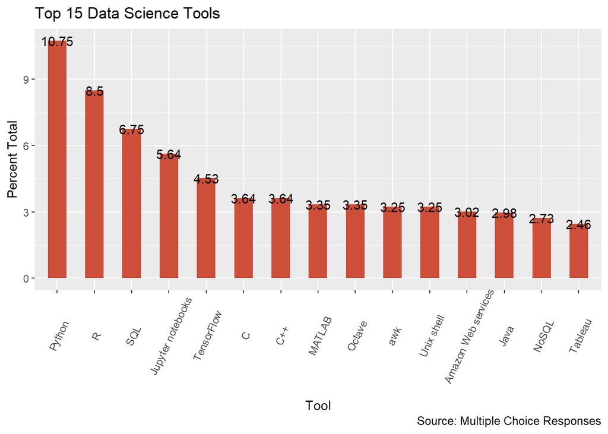

```r
ggplot(head(summary.tool.df,15), aes(x=reorder(tool, -sum_tool), y=percent_total)) +
  geom_bar(stat="identity", width=.5, fill="tomato3") +
  geom_text(aes(label=percent_total))+
  labs(x='Tool',
       y='Percent Total',
       title="Top 15 Data Science Tools",
       caption="Source: Multiple Choice Responses") +
  theme(axis.text.x = element_text(angle=65, vjust=0.6))
```

A data frame of tool frequency by id was created.

```r
frequency.data <- raw.data %>%
  select(c(1, 83:132)) %>%
  setNames(c('id', tidy.names))

id.frquency.table <-frequency.data %>%
  gather(tool_name, frequency_id, names(frequency.data)[2:51])%>%
  filter(frequency_id %in% c("Rarely", "Often",
                             "Sometimes", "Most of the time"))%>%
  arrange(id)
id.frquency.table %>% head(10) %>% kable()
```

| id | tool_name | frequency_id |
| --- | --- | --- |
| 1 | AWS | Rarely |
| 1 | Oracle | Sometimes |
| 1 | Perl | Most of the time |
| 2 | Amazon_ML | Rarely |
| 2 | AWS | Often |
| 2 | Cloudera | Rarely |
| 2 | Hadoop | Rarely |
| 2 | Impala | Rarely |
| 2 | Java | Rarely |
| 2 | Mathematica | Rarely |

I grouped the frequency information by the actual tool name & response

```r
summary.frquency.table <- frequency.data %>%
  gather(tool_name, frequency_id, names(frequency.data)[2:51])%>%
  filter(frequency_id %in% c("Rarely", "Often",
                             "Sometimes", "Most of the time"))%>%
  mutate(freq_counter =1) %>%
  group_by(tool_name,frequency_id)%>%
  summarise(sum_feq = sum(freq_counter))%>%
  arrange(desc(sum_feq))
summary.frquency.table %>% head(10) %>% kable()
```

| tool_name | frequency_id | sum_feq |
| --- | --- | --- |
| Python | Most of the time | 1022 |
| R | Most of the time | 644 |
| SQL | Most of the time | 511 |
| Python | Often | 382 |
| Jupyter | Most of the time | 366 |
| R | Often | 335 |
| SQL | Often | 300 |
| R | Sometimes | 295 |
| Python | Sometimes | 276 |
| Jupyter | Often | 271 |

The plot shows frequency of use of top technologies.

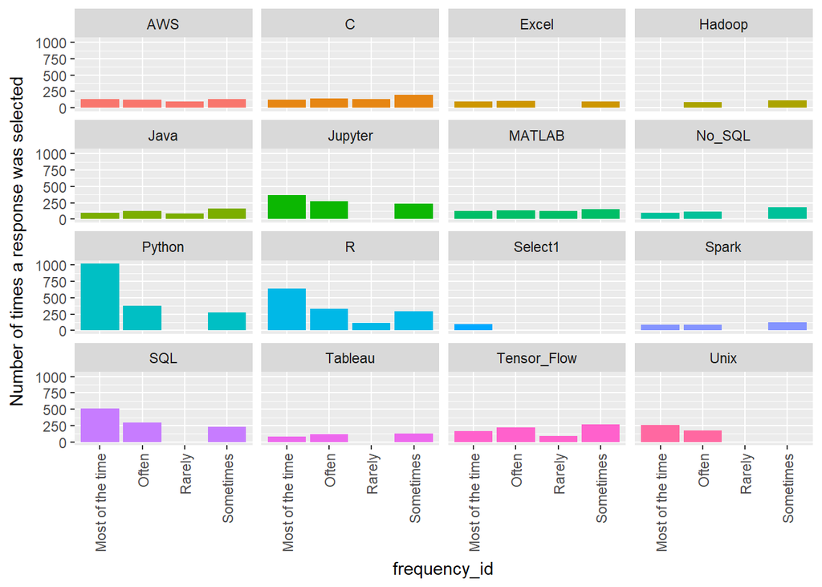

```r
ggplot(head(summary.frquency.table,50), aes(x = frequency_id, y = sum_feq, fill = tool_name)) +
  geom_bar(stat = "identity") +
  facet_wrap(~tool_name) +
  ylab("Number of times a response was selected") +
  theme(legend.position="none") +
  theme(axis.text.x = element_text(angle = 90,
                                   vjust = 0.5,
                                   hjust = 1))
```

### Work Challenges: Albert

### Conclusion (writing to csv/importing to sql?)